# Ford GoBike System Data Exploration

## by Abdullah Majed

## Dataset Overview

includes information about individual rides made in a bike-sharing system covering the greater San Francisco Bay area, it consist of 183412 row, the features include duration, user type, gender, date of birth..etc, unfourtnetly the website of orginal data is shutdown when i did this analysis you can check other systems data from this [page](https://github.com/BetaNYC/Bike-Share-Data-Best-Practices/wiki/Bike-Share-Data-Systems).

## Who are the users spend most time riding bikes ?

In this investigation, I wanted to identify the user profile who spend most time riding bikes, and when they like to ride.

### How long does the average trip take?

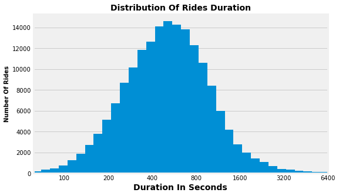

### When are most trips taken in terms of day of the week ?

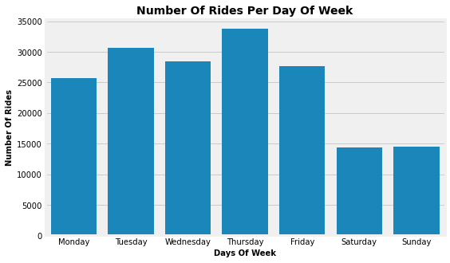

in general most rides come in week weekday rather than weekend, Thursday has the most rides almost 35000

### When are most trips taken in terms of hour of day ?

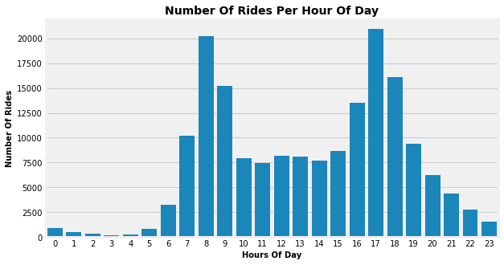

### What is the average age of our users ?

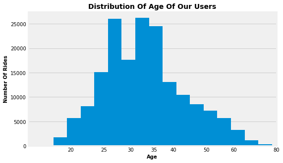

Age has a long-tailed distribution, with a lot of rides by young people, and few on by old people. When plotted on a log-scale, the age distribution looks roughly bimodal, most of people between 27 and 35

### What is the most type of the users ?

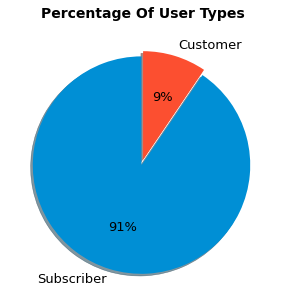

most of the users are subscribers, only `9%` are customers

### What is the most gender of the users ?

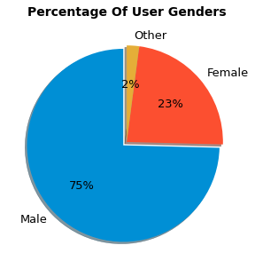

most of the users are males, only `23%` are females, and `2%` other

### When are most duration average in terms of day of the week ?

[figure not shown]

it seems people spend more time riding bikes on weekends

### When are most duration average in terms of hour of day ?

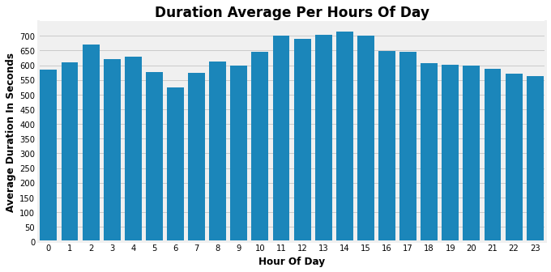

The trend change a lot, now we can see on average people spend more time riding the bike when they start between `11 AM` and `4 PM`, and the lowest duration average when they start around `6 AM`

### What is the relation between age and bike riding time ?

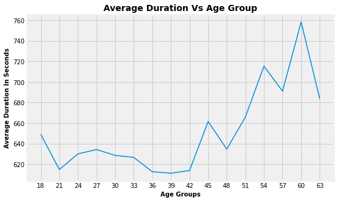

it looks like people between 45 and 63 age spend more time riding bikes.

### What user type spend more time riding bikes ?

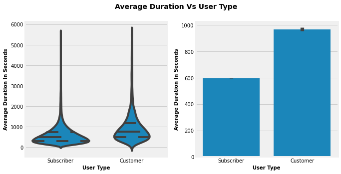

### what gender spend more time riding bikes?

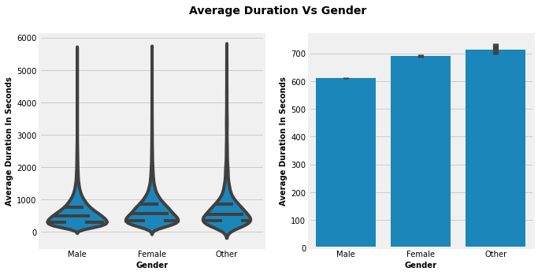

Others gender spend most time riding bike with average excede `700 sec`, females come next with average slightly below `700 sec`, lastly males is the lowest with average close to `600 sec`

### What day each user type perfer ?

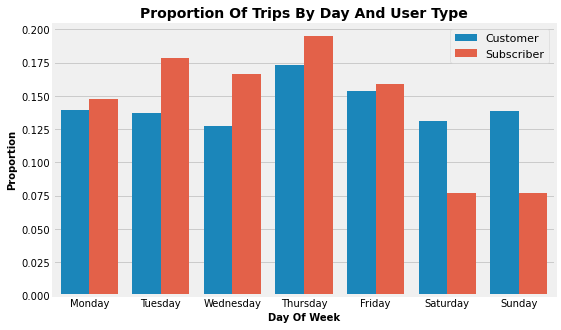

This barchart dose not show counts, instead it shows ratio of user_type count of each day to the sum of all days.

now we can see that Subscriber perfer to ride on weekdays more than Customers, but Customers perfer to ride on weekends more

### How average duration by age group differ in each user type ?

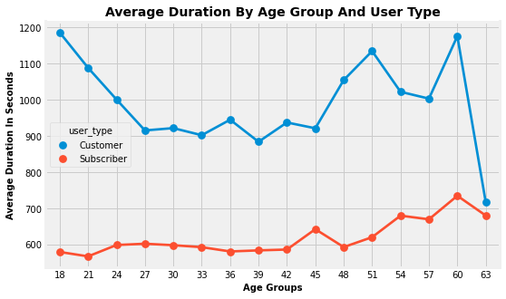

### How average duration by hour differ in each user type ?

[figure not shown]

Customers really love riding more between `10 AM` and `4 PM` with duration average between `1000 sec` and `1300 sec`

### How average duration by hour differ in each gender ?

[figure not shown]

unlike males females and others love to ride more between `0 AM` and `5 AM`, but they all ride less at `6 AM` i guess this is because it is before work, then the ride duration increases for all genders and it start decrease again at `4 PM`

### what about average age by gender in hours of the day ?

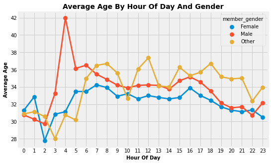

### What user type and gender combination has the most duration average ?

[figure not shown]

Female Customers have the highest duration average with `1057 sec`, male subscribers have the lowest with `581 sec`